## Programação funcional

Enfim, chegamos propriamente dito ao segundo princípio do [R](http://r-project.org/), tudo nesse ambiente é uma chamada de função. Mas lembrando que uma função é também um objeto, com suas características (atribuições) assim como os vetores também apresentam.

Parece não ser evidente, mas já pensaram quantas chamadas de função ocorrem na linha de comando a seguir?

```r
x <- mean(1:10)
```

Apesar de intuitivo, mas o símbolo de atribuição (`<-`) é uma função, `mean` é outra função, `:` também, bem como `(`. Por fim, quando digitamos o nome `x` para verificar o resultado no console, por trás existe a função `print` trabalhando para isso. Por isso, dizemos que tudo no [R](http://r-project.org/) é uma chamada de função.

Tanto no módulo básico quanto nesse módulo, já discutimos algumas propriedades importantes das funções, como o seu escopo léxico e dinâmico, a característica do ambiente [R](http://r-project.org/) ter funções de primeira classe, os ambientes envolvidos em uma função, função anônima, dentre outros assuntos.

Discutimos também que uma função do tipo `closure`, apresenta três estruturas: os argumentos (`formals()`), o corpo (`body()`) e o ambiente (`environment()`). Porém, as funções primitivas, do tipo `special` ou `buitin`, fogem a essa regra porque foram implementadas em linguagem de baixo nível, isto é, em linguagem `C`. Já mostramos também como identificar essas funções nas seções anteriores, e todas elas se encontram no pacote `base`.

Compreendemos também que uma função é chamada quando ditamos o seu nome e entre parênteses inserimos os seus argumentos. Podemos também por meio, da função `do.call()`, repassar os argumentos por meio de uma lista, que segue:

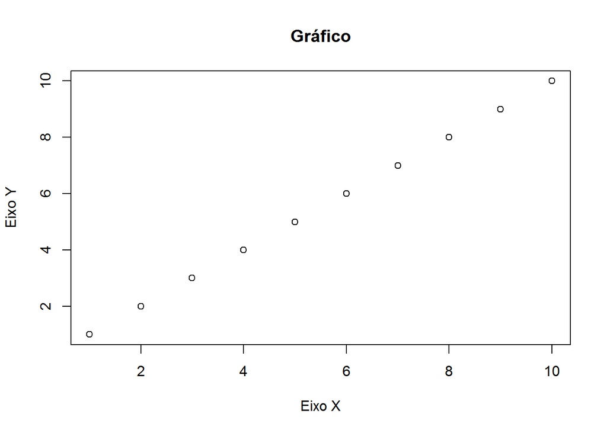

```r
argumentos <- list(x = 1:10, main = "Gráfico",
                   xlab = "Eixo X", ylab = "Eixo Y")
do.call(plot, argumentos)
```

## Composição de funções

No módulo básico, também vimos a composição de funções, construídas em blocos, aninhadas, resultados intermediários como objetos. Mas, surge uma quarta via, implementada pelo pacote [magrittr](https://magrittr.tidyverse.org/), que é o operador *pipe*. Essa ideia, segundo @hadley2019, foi inspirada nas linguagens `Haskell`, `F#`, `Julia`, `JavScript`, um estilo baseado em pilhas como *forth* e *Fator*. Esse estilo apresenta uma estrutura mais fácil de sequências de operações da esquerda para direitra, evita funções aninhadas ou definição de funções. Para a análise de dados esse operador no ambiente [R](http://r-project.org/) ganhou tanto respaldo, que foi implementado uma forma nativa na versão R 4.1. O operador *pipe* é binário, em que o primeiro operando (`lhs`) representa o valor do primeiro argumento do segundo operando (`rhs`), que representa uma função, isto é,

```r
lhs %>% rhs # Pipe do pacote 'magrittr'
lhs |> rhs  # Pipe nativo do pacote 'base'
```

| Sintaxe | Equivalência |
| --- | --- |
| `x %>% f` ou `x \|> f` | `f(x)` |
| `x %>% f(y)` ou `x \|> f(y)` | `f(x, y)` |
| `x %>% f %>% g %>% h` ou `x \|> f \|> g \|> h` | `h(g(f(x)))` |

Desse modo, podemos pensar em uma sequencia de comandos mais simples, até algo mais complexo. Vejamos o código a seguir.

```r
mtcars |> head()
```

```
##                    mpg cyl disp  hp drat    wt  qsec vs am gear carb
## Mazda RX4         21.0   6  160 110 3.90 2.620 16.46  0  1    4    4
## Mazda RX4 Wag     21.0   6  160 110 3.90 2.875 17.02  0  1    4    4
## Datsun 710        22.8   4  108  93 3.85 2.320 18.61  1  1    4    1
## Hornet 4 Drive    21.4   6  258 110 3.08 3.215 19.44  1  0    3    1
## Hornet Sportabout 18.7   8  360 175 3.15 3.440 17.02  0  0    3    2
## Valiant           18.1   6  225 105 2.76 3.460 20.22  1  0    3    1
```

```r
mtcars |> subset(cyl == 4) |> nrow()
```

```
## [1] 11
```

```r
mtcars |> subset(cyl == 4) |> (function(d) lm(mpg ~ disp, data = d))()
```

```
##
## Call:
## lm(formula = mpg ~ disp, data = d)
##
## Coefficients:
## (Intercept)         disp
##     40.8720      -0.1351
```

## Operadores binários ou unários

Na seção Manipulando vetores (Módulo básico), falamos sobre alguns operadores: matemáticos, lógicos, booleanos. Todos estes são operadores binários ou unários, que na mais são do que funções. Dizemos que um operador é unário quando há apenas a exigência de um operando na operação. Quando há a existência de dois operandos, dizemos que o operador é binário. Por exemplo, o operador soma `+` pode ser unário ou binário, pois sintaticamente, podemos escrever a operação soma com um operando ou com dois operandos. Vejamos o código a seguir.

```r
# Como operador unario
+2 # operador operando1
```

```
## [1] 2
```

```r
# Como operador binario
2 + 5 # operando1 operador operando2
```

```
## [1] 7
```

Isso significa dizer que o operador *pipe* é binário, em que o primeiro operando é um valor e o segundo operando é uma função. Alguns exemplos de operadores que também podem ser encontrados por `?Sintax`, `::`, `:::`, `$`, `@`, `[`, `[[`, `^`, `+`, `-`, `:`, `|>`, `%%`, `%/%`, `%*%`, `%x%`, `%o%`, `%in%`, `<`, `>`, `<=`, `=>`, `==`, `!=`, `!`, `&`, `&&`, `|`, `||`, `~`, `->`, `<-`, `<<-`, `=`, `?`, detre outros. Algumas dessas operações tem prevalência sobre outras, como por exemplo, no caso dos operadores matemáticos.

Para sabermos o código interno de um operador, além do nome, escrevemos aspas invertidas envolta desse nome, isto é,

[output not shown]

[output not shown]

Uma outra forma de identificarmos se um operador é binário ou unário, é verificando os seus argumentos. Por exemplo, o operador `%in%` apresenta os argumentos `x` e `table`, então no mínimo esse operador é binário. Isso ocorre porque quando verificamos os argumentos do operador soma,

```r
`+`
```

```
## function (e1, e2)  .Primitive("+")
```

percebemos que há dois argumentos, `e1` e `e2`, mas este operador pode se comportar como operador unário, é como se `e1` fosse `NULL` por padrão. Uma outra forma sintática de chamarmos um operador pode ser apresentado a seguir.

```r
`+`(e1 = 2, e2 = 5)
```

```
## [1] 7
```

Isso é o mesmo de termos realizado a operação `2 + 5`. Operadores criados pelos usuários sempre terão o símbolo de porcentagem (`%`) envolta dos nomes. Os demais operadores que não apresentam essa forma sintática são criados apenas pelo *R Core Team*.

Para ilustrar a criação de um operador, vamos fazer o nosso próprio operador *pipe*.

```r
# Nosso operador pipe '%>>%'
`%>>%` <- function(a, b) {
  aux <- as.character(substitute(b))
  exec <- call(aux, a)
  eval(exec)
}

1:10 %>>% mean()
```

```
## [1] 5.5
```

## Avaliação preguiçosa dos argumentos de uma função

Os argumentos em uma função são um tipo de objeto chamado `pairlist`, isto é,

```r
# Funcao f
f <- function(x) 1
# Tipo de objeto do argumento x
typeof(formals(f))
```

```
## [1] "pairlist"
```

esse tipo de objeto é avaliado de forma “preguiçosa”, isto é, lentamente. Isso significa dizer computacionalmente, que enquanto esse argumento não for utilizado internamente na função, ele é tipo como uma promessa e não é avaliado. Vejamos um exemplo para entendermos melhor essa afirmação.

```r
f2 <- function(x = aux()) 10; f2()
```

```
## [1] 10
```

A chamada `f2()` retorna o valor `10` sem erros, porque mesmo no argumento `x` recebendo uma função `aux()` que não existe, como internamente esse argumento não foi usado, `x` é apenas uma promessa. No ambiente [R](http://r-project.org/), não podemos manipular esse tipo de objeto, pois se assim fosse possível, o objeto deixaria de ser uma promessa.

Por causa desse tipo de estrutura, que podemos ter outros argumentos padrão como função de outros argumentos ou até como função de outros objetos criados internamente a função. Vejamos,

```r
f3 <- function(a = 4, b = a + 2, c = x * y) {
  x <- 10
  y <- 100
  list(a = a, # 4
       b = b, # a + 2
       c = c) # x * y
}
f3()
```

```
## $a
## [1] 4
##
## $b
## [1] 6
##
## $c
## [1] 1000
```

Nesse momento cabe enfatizarmos a diferença entre `<-` e `=`. Primeiro, devemos entender que qualquer um dos dois associam nomes a objetos, porém a primeira diferença existente entre os dois, é que o primeiro tem precedência superior. Vejamos o seguinte código:

```r
y <- x = 4
```

```
## Error in y <- x = 4: objeto 'y' não encontrado
```

Um outro ponto é que sintaticamente usamos o operador `=` para atribuir valores a argumentos de uma função, e `<-` para atribuir nomes a objetos, e este último deve ser a sintaxe recomendada para a atribuição de nomes a objetos.

Parece que semanticamente a atribuição de argumentos a valores são iguais, mas podemos ver que a seguir, apesar de sintaticamente as linhas de comando aparentemente idêntica, apresentam comportamentos e resultados diferentes

```r
# Funcao teste
teste <- function(x = ls()) {
  obj_ae <- "Objeto_interno"
  x
}
# ls() avaliado dentro de teste():
teste()
```

```
## [1] "obj_ae" "x"
```

```r
# ls() avaliado no ambiente de chamada:
teste(ls())
```

```
## [1] "cran"    "github"  "rlink"   "rstudio" "teste"
```

```r
teste2 <- function(){
  obj_teste2_1 <- "primeiro"
  obj_teste2_2 <- "segundo"
  obj_teste2_3 <- "terceiro"
  teste(ls())
}
teste2()
```

```
## [1] "obj_teste2_1" "obj_teste2_2" "obj_teste2_3"
```

```r
# Objeto x avaliado no ambiente global
teste((x <- ls()))
```

```
## [1] "cran"    "github"  "rlink"   "rstudio" "teste"   "teste2"
```

```r
teste((x <- ls()))
```

```
## [1] "cran"    "github"  "rlink"   "rstudio" "teste"   "teste2"  "x"
```

Na primeira situação temos a criação da função `teste` com um argumento padrão `x = ls()`. Nesse caso, `ls()` será avaliado no ambiente de execução da função, do qual pode ser confirmado com a chamada `teste()`. O segundo caso, a chamada `teste(ls())` apresenta um resultado diferente, porque `ls()`, nesse caso, foi avaliado no ambiente de chamada, que pode também ser verificado na chamada `teste2()`. Por fim, a chamada `teste((x <- ls()))` apresenta um resultado diferente com relação ao caso anterior, pois `x <- ls()` é avaliado no ambiente global, nesse caso, e não como um promessa tal como `x = ls()` foi, sendo avaliado apenas internamente no ato de sua chamada.

Por fim, podemos verificar se um argumento teve como entrada padrão, ou inserida pelo usuário, usando `missing()`. Vejamos o código, a seguir.

```r
teste <- function(arg = 5) {
  list("argumento padrão?" = missing(arg), valor = arg)
}
# Teste 1
teste()
```

```
## $`argumento padrão?`
## [1] TRUE
##
## $valor
## [1] 5
```

```r
# Teste 2
teste(4)
```

```
## $`argumento padrão?`
## [1] FALSE
##
## $valor
## [1] 4
```

## Saídas implícitas, explícitas, invisíveis de funções

No módulo Básico, mostramos a estrutura básica de como criar uma função, cujo corpo é delimitado por chaves, isto é,

```r
nova_funcao <- function(x) {
  # Corpo da funcao
  x
}
```

Nesse caso, como a última linha de comando no corpo da função `nova_funcao()` a ser avaliada é `x`, então será esta o resultado da saída da função. Observamos que nesse caso, a última linha de comando imprime o valor de `x`. Dizemos nesse caso, que a função teve uma **saída implícita**. Se ao invés, a última linha de comando fosse a associação de um nome ao objeto, nada seria retornado após a chamada de função. Vejamos o próximo exemplo para o entendimento.

```r
# Funcao com saida implicita
nova_funcao <- function(x) {
  # Corpo da funcao
  x
}
nova_funcao(2)
```

```
## [1] 2
```

```r
# Funcao com saida implicita sem resultado
nova_funcao2 <- function(x) {
  # Corpo da funcao
  x <- x
}
nova_funcao2(4)
```

Essa última chamada, acaba não aparecendo nada porque a avaliação `x <- x`, associa o nome `x` ao valor do argumento `x`, e isto não implica em imprimir esse valor. Contudo, podemos não necessariamente, apresentar como resultado de uma função, a sua última linha de comando. Nesse caso, usamos a função `return()`, para identificar qual objeto desejamos como saída para uma determinada função. Nesse caso, temos uma saída explícita.

```r
num_par_ou_impar <- function(x) {
  if (!is.numeric(x)) stop("o argumento x deve ser numerico", call. = FALSE)
  num <- as.integer(x)
  if (num %% 2 == 0) {
    return("Número par!")
  } else return("Número ímpar!")
}
# Numero real eh coagido a inteiro sem arredondamento
num_par_ou_impar(1.6)
```

```
## [1] "Número ímpar!"
```

```r
# Programacao defensiva (x deve ser numerico)
num_par_ou_impar(TRUE)
```

```
## Error: o argumento x deve ser numerico
```

```r
# Verificando se um numero eh par ou impar
num_par_ou_impar(6)
```

```
## [1] "Número par!"
```

Percebemos que todas essas saídas implícita e explícita são **saídas visíveis** após a chamada da função. Porém, podemos ter saídas invisíveis, usando a função `invisible()`. Vejamos o código a seguir.

```r
# Funcao com saida invisivel
estdes <- function(x) {
  plot(x)
  resumo <- summary(x)
  invisible(resumo)
}
# Conjunto de dados
y <- rexp(30)
# Chamando estdes
res <- estdes(y)
# Imprimindo o resultado invisivel
res
```

```
##    Min. 1st Qu.  Median    Mean 3rd Qu.    Max.
## 0.04298 0.39928 0.66783 1.00905 1.22150 3.90051
```

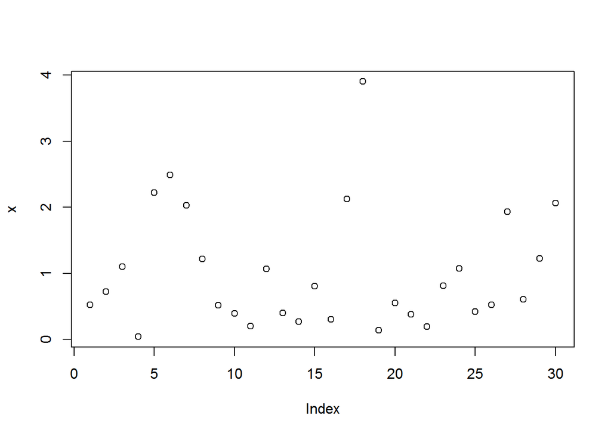

```
##    Min. 1st Qu.  Median    Mean 3rd Qu.    Max.
## 0.04298 0.39928 0.66783 1.00905 1.22150 3.90051
```

```r
# Formas alternativas
print(estdes(y))
```

```r
(estdes(y))
```

```
##    Min. 1st Qu.  Median    Mean 3rd Qu.    Max.
## 0.04298 0.39928 0.66783 1.00905 1.22150 3.90051
```

```r
# Sinalizador de visibilidade
withVisible(estdes(y))
```

```
## $value
##    Min. 1st Qu.  Median    Mean 3rd Qu.    Max.
## 0.04298 0.39928 0.66783 1.00905 1.22150 3.90051
##
## $visible
## [1] FALSE
```

```r
str(withVisible(estdes(y)))
```

```
## List of 2
##  $ value  : 'summaryDefault' Named num [1:6] 0.043 0.399 0.668 1.009 1.221 ...
##   ..- attr(*, "names")= chr [1:6] "Min." "1st Qu." "Median" "Mean" ...
##  $ visible: logi FALSE
```

Um caso específico de função com resultado invisível é a atribuição (`<-`). Quando associamos um nome a um objeto, a saída dessa função é invisível, a menos que redigite o nome no console ou use entre parênteses essa linha de comando, isto é,

```r
# Funcao `<-`() com saida invisivel
x <- 10
# Acessando o valor do obj associado com o nome 'x'
x
```

```
## [1] 10
```

```r
# Outra forma de acesso
(x <- 10)
```

```
## [1] 10
```

## Funções de substituição

Muito provavelmente, ao importar um banco de dados, armazenados em um objeto de classe *data.frame*, tivemos algum problema de erro em algum valor em nossas variáveis em estudo. Por exemplo, consideremos um banco de dados com informações de um grupo de pessoas, tais como o nome, altura (cm), peso (kg), idade (anos), que segue:

```r
dados <- data.frame(
  nome = c("Paulo", "Maria", "Caio"),
  altura = c(175, 167, 172),
  peso = c(70, 65, 7500),
  idade = c(32, 26, 19)
); dados
```

```
##    nome altura peso idade
## 1 Paulo    175   70    32
## 2 Maria    167   65    26
## 3  Caio    172 7500    19
```

Se esse banco foi importado, podemos alterar no próprio banco. Caso contrário, pode ser realizado uma substituição do valor no próprio ambiente [R](http://r-project.org/) para o objeto específico, usando `[`, ou similares, dependendo do tipo de objeto. Para esse caso, percebemos que o peso de Caio (7500kg), muito provavelmente foi um erro de digitação, e e que na realidade seria 75kg como correção. Para fazermos essa alteração em `dados`, uma das possibilidades seria usar a função de substituição `dados[3, 3] <- 75`, em que a mudança ocorre na terceira linha e 3 coluna do *data.frame*. Como poderíamos criar uma função de substituição? Usando as mesmas ideias usadas nesse caso. A função de substituição para um caso geral, é dado da seguinte forma sintática:

```r
`[<-` <- function(x, i, value){
  # Corpo da funcao
}
# Chamada de funcao
x[i] <- value
# Chamada de forma equivalente
`[<-`(x, i, value)
```

Claro que isso não é um padrão, mas uma ideia geral para a chamada `[<-`, que basicamente deve ter dois argumentos, `x` e `value`. O primeiro é o objeto em que há a necessidade de substituição de um de seus valores, e o segundo representa o valor para a substituição. Argumentos adicionais a estes, devem ser colocados entre esses argumentos, e à esquerda do argumento `value`, que foi o caso do argumento `i`, que representa a posição do elemento a ser substituído no objeto `x`. Por outro lado, devemos evitar a substituição de funções internas, como no caso da função `(<-`, por exemplo, uma vez que funções como essas usadas a todo momento em um código, pode trazer conflitos entre essas funções.

Vamos aprofundar um pouco mais essa questão, usando um exemplo mais simples para a compreensão, a seguir.

```r
# Vamos criar um vetor de comprimento 10
x <- 1:10; x
```

```
##  [1]  1  2  3  4  5  6  7  8  9 10
```

```r
# Usando a funcao de substituicao, para alterar
# dois valores na posicao 6 e 10
x[c(6, 10)] <- c(100, 200); x
```

```
##  [1]   1   2   3   4   5 100   7   8   9 200
```

O que ocorre por trás, cuja referência pode ser confirmada no manual [R Language Definition, seção 3.4.4](https://cran.r-project.org/doc/manuals/r-release/R-lang.html#Subset-assignment), é que surge a criação de um nome temporário `` `*tmp*` `` que também se associa ao mesmo objeto associado ao nome `x`, cujas alterações são realizadas em `` `*tmp*` ``, e um novo objeto é criado e um novo nome se associa a ele, e para deixar a impressão de que a alteração é ocorrida no próprio objeto, esse novo nome é exatamente `x`, igual ao nome antigo.

```r
# Objeto x criado
x <- 1:10
# `*tmp*` temporariamente criado
`*tmp*` <- x
# Alteracoes realizadas
x <- `[<-`(`*tmp*`, c(6, 10), valor = c(100, 200)); x
```

```
##  [1]   1   2   3   4   5 100   7   8   9 200
```

```r
# Ao final se remove `*tmp*`
rm(`*tmp*`)
```

Por fim, `` `*tmp*` `` é removido, e nesse caso, ocorre a cópia do objeto, como pode ser verificado por meio chamada `tracemen()`, isto é,

```r
# Vamos criar um vetor de comprimento 10
x <- 1:10; x
## [1]  1  2  3  4  5  6  7  8  9 10

# Inspecionando o objeto
tracemem(x)
## [1] "<000000965C8A97D8"

.Internal(inspect(x))
## @0x000000965c8a97d8 13 INTSXP g0c0 [REF(65535),TR]  1 : 10 (compact)

# Usando a funcao de substituicao, para alterar
# dois valores na posicao 6 e 10
x[c(6, 10)] <- c(100, 200); x
## tracemem[0x000000965c8a97d8 - 0x000000965bdf6bc0]:
## tracemem[0x000000965bdf6bc0 - 0x000000965f177418]:
## [1]   1   2   3   4   5 100   7   8   9 200

# Inspecionando novamente o objeto
.Internal(inspect(x))
## @0x000000965f177418 14 REALSXP g0c5 [REF(5),TR] (len=10, tl=0) 1,2,3,4,5,...
```

Observamos inicialmente `x` (id `0x000000965c8a97d8`), cujo nome `` `*tmp*` `` inicialmente se liga ao mesmo objeto, e após as substituições `` `*tmp*` `` passa a está alocado a um novo espaço de memória (id `0x000000965f177418`), isto é ocorre uma cópia. A cópia intermediária (id `0x000000965bdf6bc0`) que ocorre no processo é devido a chamada `` `:`() ``. Mas a pergunta que fica, como fica o entendimento da otimização de desempenho especial a **modificação no local**? Bem, o nosso entendimento para o caso de vetores, como já mostrado anteriormente, a ideia estará sempre na contagem de referência. Já vimos, que para a chamada `` `:`() ``, a primeira modificação realizada no objeto será modificação em cópia, pois `REF(# > 1)`. Nesse caso, que foi o exemplo mostrado anteriormente, existe a presença de `` `*tmp*` `` por trás dos bastidores. Entretanto, quando o vetor é desenvolvido pela chamada `c()`, sabemos que a alteração do objeto ocorre em modificação no local, quando não alteraramos a dimensão do vetor, mas apenas os valores. Bem, o que indagamos é a existência ou não do nome temporário `` `*tmp*` `` no processo. Como falamos na seção em sobre cópia de objetos, afirmamos que um dos pré-requisitos para a modificação no local, é que o objeto só pode ter uma ligação, isto é, um nome associado ao objeto. E quando mostramos a forma sintática da função de substituição `` `[<- `() ``, percebemos que `x` e `` `*tmp*` `` se ligam ao mesmo objeto inicialmente, e assim, teoricamente deveria sempre haver cópia com a alteração de algum dos valores desse objeto. Desse modo, pressupomos que para esses casos de modificação no local, o processo seja um pouco diferente desse processo. Contudo, isso só ocorrerá para o caso da função de substituição primitiva (`[<-`), implementada em linguagem `C`. Quando desenvolvemos nossas próprias funções de substituição, aí sempre ocorrerá cópia na modificação.

Para desenvolvermos as nossas próprias funções de substituição apresentamos um exemplo, criando a função `` `substextr<-`() ``, a seguir.

```r
# Funcao de substituicao de alterar os extremos
`substextr<-` <- function(x, value) {
  x <- sort(x)
  x[1] <- x[length(x)] <- value
  x
}
# Criando o vetor
set.seed(10)
x <- rnorm(10)
# Inspecao
.Internal(address(x))
```

```
## <pointer: 0x00000000112309c0>
```

```r
# Alterando o vetor
substextr(x) <- 100
# Inspecao
.Internal(address(x))
```

```
## <pointer: 0x0000000011230180>
```

Nesse caso, obrigatoriamente os dois argumentos básicos e com esses nomes são `x` e `value`, sendo que `value` deve ser sempre o último argumento. Caso, seja necessário adicionar mais argumentos, estes devem ser inseridos entre esses dois argumentos, como apresentado no código a seguir.

```r
`subst<-` <- function(x, i, value) {
  x[i] <- value
  x
}
set.seed(10)
(x <- c(1, 2, 3))
```

```
## [1] 1 2 3
```

```r
# Inspecao
.Internal(address(x))
```

```
## <pointer: 0x000000001183e168>
```

```r
# subst(x, i) <- value
subst(x, 2) <- 100; x
```

```
## [1]   1 100   3
```

```r
# Inspecao
.Internal(address(x))
```

```
## <pointer: 0x00000000118c8848>
```

## Vetorização de funções

A vetorização de funções surge quando inserimos argumentos vetorizados, cuja saída dessas funções também são vetorizadas, de modo que não precisamos de *loop* para que a função retorne um valor de cada elemento do vetor de algum dos argumentos. Pensemos no operador soma (`+`), no seguinte código:

```r
# Vetorização da soma de vetores
1:4 + 10:13
```

```
## [1] 11 13 15 17
```

Essa função é vetorizada porque ela realizou, porque ela realizou a soma entre dois elementos de mesma posição nos vetores, isto é,

```r
1  2  3  4
+  +  +  +
10 11 12 13
------------
11 13 15 17
```

Isso é como se tivéssemos realizado um *loop* para essa operação, da seguinte forma:

```r
x <- 1:4
y <- 10:13
for (i in 1:4) {
  print(x[i] + y[i])
}
```

```
## [1] 11
## [1] 13
## [1] 15
## [1] 17
```

Grande maioria das funções nativas do [R](http://r-project.org/), isto é, das funções desenvolvidas nos pacotes nativos são vetorizados. Vejamos alguns exemplos:

```r
# Funcao logaritmica
log(1:4)
```

```
## [1] 0.0000000 0.6931472 1.0986123 1.3862944
```

```r
# Multiplicacao
10:20 * 5
```

```
##  [1]  50  55  60  65  70  75  80  85  90  95 100
```

```r
# Operadores logicos
1 == 1:4
```

```
## [1]  TRUE FALSE FALSE FALSE
```

```r
# Gerador de numeros aleatorios [0, 1]
runif(1:10)
```

```
##  [1] 0.50747820 0.30676851 0.42690767 0.69310208 0.08513597 0.22543662
##  [7] 0.27453052 0.27230507 0.61582931 0.42967153
```

Existem diversos caminhos para se desenvolver uma função vetorizada. Caso as funções internas da função desenvolvida seja vetorizada, esta também será. Vejamos:

```r
`%soma%` <- function(e1, e2) {
  e1 + e2
}
# Exemplo 1
1:4 %soma% 10:13
```

```
## [1] 11 13 15 17
```

```r
# Exemplo 2
1:4 %soma% 5
```

```
## [1] 6 7 8 9
```

Quando temos funções escalares, podemos em uma das possibilidades, utilizar a função `Vectorize()` para vetorizar a função desejada. Essa função tem três argumentos importantes, `FUN` que representa a função a ser vetorizada `vectorize.args` que representa os argumentos da função vetorizado, que devem entrar como vetores caracteres nesse argumento, e `SIMPLIFY` que é um argumento lógico, cujo valor `TRUE` representa uma saída em forma de matriz, dependendo da situação, e `FALSE` representa a saída em forma de lista. Argumentos padrão não são vetorizados.

Vamos usar como exemplo, a função que gera números aleatórios de uma distribuição normal, `rnorm(n, mean, sd, log)`. Vamos trabalhar apenas com os três primeiros argumentos, em que `n` representa o tamanho da amostra, `mean` o parâmetro média e `sd` o parâmetro desvio padrão. Vamos fixar `n = 10` e `sd = 1`, e variar `mean = 1:3`. Isto significa que iremos ter valores baseados em uma distribuição normal, tal que os valores $X_i$, para $i = 1, 2, \ldots, 10$, serão gerados de distribuições, tal que $X_i \sim N(\mu_j)$, sequencialmente para $\mu_1 = 1$, $\mu_2 = 2$ e $\mu_3$, respectivamente. Assim, teremos uma amostra de tamanho 10, da seguinte forma: $X_1\sim N(1,1)$, $X_2\sim N(2,1)$, $X_3\sim N(3,1)$, $X_4\sim N(1,1)$, $X_5\sim N(2,1)$, $X_6\sim N(3,1)$, $X_7\sim N(1,1)$, $X_8\sim N(2,1)$, $X_9\sim N(3,1)$, $X_{10}\sim N(1,1)$. Vejamos o código a seguir.

```r
# Semente
set.seed(10)
# Gerando a amostra
rnorm(10, 1:3, 1)
```

```
##  [1]  1.0187462  1.8157475  1.6286695  0.4008323  2.2945451  3.3897943
##  [7] -0.2080762  1.6363240  1.3733273  0.7435216
```

Vamos supor agora, que a ideia de vetorização para essa função, seja que quando assumimos `mean = 1:3`, ao invés de termos uma amostra como a anterior, teremos três amostras baseadas no comprimento do vetor em `mean`. Fixado os demais argumentos, teremos uma amostra de uma normal para $\mu_1 = 1$, $\mu_2 = 2$ e $\mu_3 = 3$, isto é,

$$\left\{\begin{array}{ll}
X_1, X_2, \ldots, X_{10}, & X_i \sim N(1,1), \\
Y_1, Y_2, \ldots, Y_{10}, & Y_i \sim N(2,1), \\
Z_1, Z_2, \ldots, Z_{10}, & Z_i \sim N(3,1).
\end{array}\right.$$
Para isso, iremos usar `Vectorize()` para `rnorm()`, vetorizando o argumento `mean`. Vejamos o código a seguir, para essa implementação.

```r
# Apos a vetorizacao, observe a diferenca entre
# 'rnorm_vet1' e 'rnorm_vet2', devido ao argumento
# 'SIMPLIFY'
rnorm_vet1 <- Vectorize(rnorm, "mean", SIMPLIFY = FALSE)
rnorm_vet2 <- Vectorize(rnorm, "mean", SIMPLIFY = TRUE)
# Vetorizando
set.seed(10) # semente para fixar os mesmos valores
rnorm_vet1(n = 10, mean = 1:3)
```

```
## [[1]]
##  [1]  1.0187462  0.8157475 -0.3713305  0.4008323  1.2945451  1.3897943
##  [7] -0.2080762  0.6363240 -0.6266727  0.7435216
##
## [[2]]
##  [1] 3.101780 2.755782 1.761766 2.987445 2.741390 2.089347 1.045056 1.804850
##  [9] 2.925521 2.482979
##
## [[3]]
##  [1] 2.4036894 0.8147132 2.3251341 0.8809388 1.7348020 2.6263384 2.3124446
##  [8] 2.1278412 2.8982390 2.7462195
```

```r
set.seed(10) # semente para fixar os mesmos valores
rnorm_vet2(n = 10, mean = 1:3)
```

```
##             [,1]     [,2]      [,3]
##  [1,]  1.0187462 3.101780 2.4036894
##  [2,]  0.8157475 2.755782 0.8147132
##  [3,] -0.3713305 1.761766 2.3251341
##  [4,]  0.4008323 2.987445 0.8809388
##  [5,]  1.2945451 2.741390 1.7348020
##  [6,]  1.3897943 2.089347 2.6263384
##  [7,] -0.2080762 1.045056 2.3124446
##  [8,]  0.6363240 1.804850 2.1278412
##  [9,] -0.6266727 2.925521 2.8982390
## [10,]  0.7435216 2.482979 2.7462195
```

As únicas funções que não podem ser vetorizadas por `Vectorize()` são as funções primitivas que não tem um valor para `formals()`.

Uma outra forma de vetorizar funções, por exemplo, bem como evitar *loops* no desenvolvimento de algoritmos, é utilizar um conjunto de funções da família *apply* implentadas no pacote `base`, que será vista a seguir.

## Funções da família *apply*

Apesar de uma das construções mais interessantes na programação, seja o *loop*, é bom observar que essas construções implementadas em diversas linguagens apresenta grandes diferenças, em termos de desempenho. Já vimos que as funções para *loops* no [R](http://r-project.org/) pode demandar um gasto computacional dependendo de sua implementação, cópias na modificação, por ser uma linguagem interpretada, dentre outras características. Alternativamente, podemos usar uma série de funções implementadas no ambiente [R](http://r-project.org/), funções estas vetorizadas. Vamos nos concentrar nas funções disponíveis na Base [R](http://r-project.org/).

Iniciamos com a família de funções *apply*, pertencente ao pacote `base`, de modo que permite manipularmos estruturas de dados como vetores, matrizes, *arrays*, listas e quadro de dados (*data frames*) de maneira repetitiva sem a utilização de *loop*. Estas funções são: `apply()`, `lapply()`, `sapply()`, `tapply()`, `mapply()`, `rapply()` e `eapply()`

A primeira função a ser discutida é `apply()`, que retorna um *array* ou uma lista obtida pela aplicação de uma função nas linhas ou colunas da entrada de um objeto seja matriz ou *array*. Vejamos a sintaxe dessa função:

```r
apply(X, MARGIN, FUN, ..., simplify = TRUE),
```

em que: - `X` argumento que recebe o objeto matriz ou *array*, - `MARGIN` argumento que recebe `1`, se a função em `FUN` deve ser aplicado na linha, ou recebe `2` se `FUN` deve ser aplicado nas colunas, - `FUN` argumento que recebe a função desejada, - `...` argumento que recebe argumentos adicionais para `FUN`, e - `simplify` argumento lógico para retorno de resultados simplificados (`TRUE`) ou não (`FALSE`).

Por exemplo, supomos que temos 5 amostras de tamanho 10, com reposição, em um conjunto de valores de 1 a 1000, e desejamos computar a média aritmética dessas amostras, que serão inseridas em colunas num objeto matriz, isto é,

```r
# 5 amostras
(am1 <- sample(x = 1:1000, size = 10, replace = TRUE))
```

```
##  [1]  42 334  13 417 361 729 712 656 373  26
```

```r
(am2 <- sample(x = 1:1000, size = 10, replace = TRUE))
```

```
##  [1] 857 209  48 663 527 958 878 536 482 317
```

```r
(am3 <- sample(x = 1:1000, size = 10, replace = TRUE))
```

```
##  [1] 132 739 270 929  35 266  74 570 679 912
```

```r
(am4 <- sample(x = 1:1000, size = 10, replace = TRUE))
```

```
##  [1] 271 543 906 101 435 437 959 613 621 943
```

```r
am5 <- sample(x = 1:1000, size = 10, replace = TRUE)
# Amostras em colunas
amost_col <- matrix(c(am1, am2, am3, am4, am5), 10, 5); amost_col
```

```
##       [,1] [,2] [,3] [,4] [,5]
##  [1,]   42  857  132  271   39
##  [2,]  334  209  739  543  947
##  [3,]   13   48  270  906  630
##  [4,]  417  663  929  101   89
##  [5,]  361  527   35  435  530
##  [6,]  729  958  266  437  899
##  [7,]  712  878   74  959  982
##  [8,]  656  536  570  613  554
##  [9,]  373  482  679  621  394
## [10,]   26  317  912  943  254
```

```r
# Calculando a media por coluna
apply(X = amost_col, MARGIN = 2, FUN = mean)
```

```
## [1] 366.3 547.5 460.6 582.9 531.8
```

```r
# Amostras em linhas
amost_lin <- matrix(c(am1, am2, am3, am4, am5), 5, 10, byrow = TRUE); amost_lin
```

```
##      [,1] [,2] [,3] [,4] [,5] [,6] [,7] [,8] [,9] [,10]
## [1,]   42  334   13  417  361  729  712  656  373    26
## [2,]  857  209   48  663  527  958  878  536  482   317
## [3,]  132  739  270  929   35  266   74  570  679   912
## [4,]  271  543  906  101  435  437  959  613  621   943
## [5,]   39  947  630   89  530  899  982  554  394   254
```

```r
# Calculando a media por linhas
apply(X = amost_lin, MARGIN = 1, FUN = mean)
```

```
## [1] 366.3 547.5 460.6 582.9 531.8
```

```r
# Podemos tambem adicionar argumentos adicionais
# em FUN (Media truncada em 10%)
apply(X = amost_lin, MARGIN = 1, FUN = mean, trim = 0.1)
```

```
## [1] 365.125 558.625 455.250 596.125 537.125
```

```r
# Usando o argumento simplify, o default: simplify = TRUE
apply(X = amost_lin, MARGIN = 1, FUN = mean, simplify = FALSE)
```

```
## [[1]]
## [1] 366.3
##
## [[2]]
## [1] 547.5
##
## [[3]]
## [1] 460.6
##
## [[4]]
## [1] 582.9
##
## [[5]]
## [1] 531.8
```

A próxima função é `lapply()`, com sintaxe:

```r
lapply(X, FUN, ...),
```

em que: - `X` argumento que recebe uma lista; - `FUN` argumento que recebe a função desejada, e - `...` argumento que recebe argumentos adicionais para `FUN`.

Vejamos que a sintaxe desta função é muito parecido com `apply()`. Vejamos alguns exemplos, a seguir.

```r
# Vetor (nao faz muito sentido)
lapply(1:10, mean)
```

```
## [[1]]
## [1] 1
##
## [[2]]
## [1] 2
##
## [[3]]
## [1] 3
##
## [[4]]
## [1] 4
##
## [[5]]
## [1] 5
##
## [[6]]
## [1] 6
##
## [[7]]
## [1] 7
##
## [[8]]
## [1] 8
##
## [[9]]
## [1] 9
##
## [[10]]
## [1] 10
```

```r
# Lista
lapply(list(x = 1:10, y = 11:20), mean)
```

```
## $x
## [1] 5.5
##
## $y
## [1] 15.5
```

```r
lapply(list(x = 1:10, y = 11:20), "[[", 2)
```

```
## $x
## [1] 2
##
## $y
## [1] 12
```

```r
lapply(list(mat1 = matrix(1:12, 4, 3)), "[", , 2)
```

```
## $mat1
## [1] 5 6 7 8
```

A função seguinte é `sapply()`, que é um invólucro (*wrapper*) da função `lapply()`, e o acréscimo sintátivo do argumento padrão `simplify = TRUE`. Assim, a forma sintática dessa função, segue:

```r
sapply(X, FUN, ..., simplify = TRUE, USE.NAMES = TRUE),
```

em que: - `X` argumento que recebe uma lista; - `FUN` argumento que recebe a função desejada; - `...` argumento que recebe argumentos adicionais para `FUN`; e - `simplify`, argumento lógico, se `TRUE` retorna o resultado de forma simplificada, sendo um vetor atoômico, matriz ou *array*; se `FALSE` o retorno é uma lista; - `USE.NAMES`, argumento lógico; se `TRUE` é retornado o nome inserido nos objetos da lista; se `FALSE`, caso contrário.

Na realidade, o que essa função faz é melhorar a saída de `lapply()`, retornando um vetor, matriz ou *array*. Vejamos,

```r
lapply(list(1:10, 11:20), mean)
```

```
## [[1]]
## [1] 5.5
##
## [[2]]
## [1] 15.5
```

```r
sapply(list(1:10, 11:20), mean)
```

```
## [1]  5.5 15.5
```

```r
# 'simplify = FALSE' em 'sapply()' eh equivalente a 'lapply()'
sapply(list(1:10, 11:20), mean, simplify = FALSE)
```

```
## [[1]]
## [1] 5.5
##
## [[2]]
## [1] 15.5
```

Uma forma multivariada da função `apply`, é a função `mapply()`, com sintaxe:

```r
mapply(FUN, ..., MoreArgs = NULL, SIMPLIFY = TRUE,
       USE.NAMES = TRUE)
```

em que: - `FUN` argumentos que recebe a função desejada; - `...` argumentos para vetorização; - `MoreArgs` uma lista com argumentos adicionais a `FUN`; - `SIMPLIFY`, argumento lógico, se `TRUE` retorna o resultado de forma simplificada, sendo um vetor atoômico, matriz ou *array*; se `FALSE` o retorno é uma lista; - `USE.NAMES`, argumento lógico; se `TRUE` é retornado o nome inserido nos objetos da lista; se `FALSE`, caso contrário.

Vejamos alguns exemplos de aplicação, a seguir.

```r
mapply(FUN = mean, list(x = 1:10, y = 11:20), USE.NAMES = TRUE)
```

```
##    x    y
##  5.5 15.5
```

```r
mapply(FUN = mean, list(x = 1:10, y = 11:20), USE.NAMES = FALSE)
```

```
## [1]  5.5 15.5
```

```r
mapply(FUN = rep, x = 1:4,  times = 1:4)
```

```
## [[1]]
## [1] 1
##
## [[2]]
## [1] 2 2
##
## [[3]]
## [1] 3 3 3
##
## [[4]]
## [1] 4 4 4 4
```

```r
mapply(FUN = rep, x = 1:4,  times = 4)
```

```
##      [,1] [,2] [,3] [,4]
## [1,]    1    2    3    4
## [2,]    1    2    3    4
## [3,]    1    2    3    4
## [4,]    1    2    3    4
```

```r
mapply(rep, times = 1:4, MoreArgs = list(x = 4))
```

```
## [[1]]
## [1] 4
##
## [[2]]
## [1] 4 4
##
## [[3]]
## [1] 4 4 4
##
## [[4]]
## [1] 4 4 4 4
```

```r
mapply(sample, size = rep(38, 10), MoreArgs = list(x = 1:38))
```

```
##       [,1] [,2] [,3] [,4] [,5] [,6] [,7] [,8] [,9] [,10]
##  [1,]   15   13   14   31   23   29   18    1   32    25
##  [2,]   13    6   30   17    1   24   31   37   36    35
##  [3,]   26   37   27   37   37    5   37   21    7     7
##  [4,]   14   12   10   24   19   25   33   22   25    10
##  [5,]   28   32    8    7   25   32   20   26    3    23
##  [6,]    4   31    6   27    6   14   35    4   31    15
##  [7,]   31    4    5   14   33   13   19   35   37    28
##  [8,]   20   24    9   10   14   11   27   18    9    14
##  [9,]   29   21   18    6   30   22   25   12   11    24
## [10,]    3   18   15   34   15    1   17   24   18     6
## [11,]   23   38   16    4    7   28   21   36   15    37
## [12,]   17   23   17    1   10   19   10   30   16    18
## [13,]   16   17   23   20   31    7   13   27   21     5
## [14,]   32   11   38   13    2    4   34   38   29    32
```

[output cut: 24 more lines]

Poderíamos estar interessados também em gerar 10 amostras de tamanho $n = 30$, de uma distribuição normal padrão, isto é,

```r
mapply(rnorm, n = rep(30, 10))
```

```
##              [,1]        [,2]         [,3]       [,4]        [,5]        [,6]
##  [1,]  0.97693997  1.02159557  0.128783463 -1.8656023 -1.70899030 -0.76589869
##  [2,]  0.79023781  0.35895923  1.972929865 -0.3264478  0.58183916  0.68909301
##  [3,]  0.98468618  1.25387555 -0.071548470  0.4604034  0.36406946 -0.47754641
##  [4,]  1.72802155  0.70613372  0.662564612 -0.3511606  1.51223372  1.74790082
##  [5,] -0.12590361 -1.94721263 -0.021996069  0.7167607  0.19003523  1.61613864
##  [6,]  2.53435299 -0.11707933 -0.316477912 -0.2088030  0.57913457 -0.67747280
##  [7,] -0.43306272  0.17854140  0.002216812  1.2765002  0.05312193 -1.06211418
##  [8,]  0.05448099 -0.88326729  0.518168763 -1.1883914  0.92380619  0.88842467
##  [9,]  0.21240835 -0.80757517  1.052712115 -1.7137380  0.14522949 -1.19553994
## [10,] -0.89938361  0.10100343  1.860744440 -1.9561878 -0.88649435  1.42369200
## [11,] -1.37565361  1.46412309 -0.572562971 -1.3176539  0.37985772 -0.20078225
## [12,] -0.72000035 -0.10547712 -1.116260285  0.4809290 -0.94199625  1.32816470
## [13,]  0.57103300 -1.79153520 -0.943473638  0.1418312 -0.48406717  2.23539357
## [14,] -2.22797642  0.54351301 -2.224035530 -0.2452919 -0.23334446  0.34765519
```

[output cut: 47 more lines]

- Outras funções: `by()`, `aggregate()`, `simplify2array()`, `ave()`, `replicate()`, `outer()`

## Funções recursivas

- `Recall()`
- `local()`

## Programação defensiva

## Exemplo

### Função `stop()`

### Função `Warning()`